# PROYECTO FINAL

Eduardo Alejandro Arrieta Donato

Como parte final del módulo correspondiente a la materia Bioinformática del 4to semestre de la Licenciatura en Ciencias Genómicas impartido por Leonardo Collado Torres sobre análisis de resultados de ensayos de RNA-seq usando R, se presenta un proyecto de análisis que cumpla con las siguientes condiciones:

- Con datos de algún estudio disponible vía recount3, hagan un análisis de expresión diferencial.
- Incluyan al menos 3 gráficas en su reporte.

Para este caso, se usarán los datos de un trabajo titulado “*Single cell transcriptional dynamics of flavivirus infection*” obtenido vía `recount3` con su id_project `SRP132726`.

Dicho trabajo consiste en una serie de ensayos viscRNA-Seq (RNA-Seq de célula única que incluye virus), un enfoque para sondear el transcriptoma del huésped junto con el RNA viral intracelular a nivel de célula única. Se aplica viscRNA-Seq para monitorear la infección por el virus del dengue y el Zika en células cultivadas,

Por lo que se busca en este proyecto obervar aquellos genes que cuenten con una expresión alta durante la infección para dar pauta a futuras investigaciones.

```r
library("recount3")
```

```r
# Primero debemos obtener los proyectos relacionados al humano
human_projects <- available_projects(organism = "human")
```

```
## 2021-03-01 04:13:45 caching file sra.recount_project.MD.gz.
```

```
## 2021-03-01 04:13:47 caching file gtex.recount_project.MD.gz.
```

```
## 2021-03-01 04:13:48 caching file tcga.recount_project.MD.gz.
```

```r
# Despues se obtiene el experimento con su id
proj_info <- subset(
    human_projects,
    project == "SRP132726" & project_type == "data_sources"
)

rse_gene_SRP132726 <- create_rse(proj_info)
```

```r
rse_gene_SRP132726
```

```
## class: RangedSummarizedExperiment
## dim: 63856 2260
## metadata(8): time_created recount3_version ... annotation recount3_url
## assays(1): raw_counts
## rownames(63856): ENSG00000278704.1 ENSG00000277400.1 ...
##   ENSG00000182484.15_PAR_Y ENSG00000227159.8_PAR_Y
## rowData names(10): source type ... havana_gene tag
## colnames(2260): SRR6711591 SRR6711614 ... SRR6712981 SRR6712983
## colData names(175): rail_id external_id ...
##   recount_pred.curated.cell_line BigWigURL
```

```r
# El experimento cuenta con cuentas crudas de lecturas
```

```r
assay(rse_gene_SRP132726, "counts") <- compute_read_counts(rse_gene_SRP132726)
# Por lo que hay que contabilizarlas para el estudio
rse_gene_SRP132726
```

```
## class: RangedSummarizedExperiment
## dim: 63856 2260
## metadata(8): time_created recount3_version ... annotation recount3_url
## assays(2): raw_counts counts
## rownames(63856): ENSG00000278704.1 ENSG00000277400.1 ...
##   ENSG00000182484.15_PAR_Y ENSG00000227159.8_PAR_Y
## rowData names(10): source type ... havana_gene tag
## colnames(2260): SRR6711591 SRR6711614 ... SRR6712981 SRR6712983
## colData names(175): rail_id external_id ...
##   recount_pred.curated.cell_line BigWigURL
```

```r
rse_gene_SRP132726$sra.sample_attributes[1:5]
```

```
## [1] "barcode;;Barcode_724-510EX2|cell line;;huh7|experiment;;10017006|index;;ACTGAGCG-TCTAATTGCA|moi;;10|n_dengue_molecules;;2187|source_name;;huh7|virus-qpcr;;0.105|virus;;dengue"
## [2] "barcode;;Barcode_701-517EX3|cell line;;huh7|experiment;;10017006|index;;TAAGGCGA-GTAAGACTAG|moi;;0|n_dengue_molecules;;0|source_name;;huh7|virus;;dengue"
## [3] "barcode;;Barcode_701-518EX3|cell line;;huh7|experiment;;10017006|index;;TAAGGCGA-ATTAAGCTAG|moi;;0|n_dengue_molecules;;0|source_name;;huh7|virus;;dengue"
## [4] "barcode;;Barcode_701-521EX3|cell line;;huh7|experiment;;10017006|index;;TAAGGCGA-GCCTTACTAG|moi;;0|n_dengue_molecules;;0|source_name;;huh7|virus;;dengue"
## [5] "barcode;;Barcode_701-522EX3|cell line;;huh7|experiment;;10017006|index;;TAAGGCGA-ATGCGACTAG|moi;;0|n_dengue_molecules;;0|source_name;;huh7|virus;;dengue"
```

```r
# La parte |virus-qpcr;;...| no existe para todas las muestras
# Quitando esta opción normalizamos la variable quitando ruido
```

```r
# Sustitucion
rse_gene_SRP132726$sra.sample_attributes <- gsub("virus-qpcr;;[0-9.]+\\|", "", rse_gene_SRP132726$sra.sample_attributes)

rse_gene_SRP132726$sra.sample_attributes[1:5]
```

```
## [1] "barcode;;Barcode_724-510EX2|cell line;;huh7|experiment;;10017006|index;;ACTGAGCG-TCTAATTGCA|moi;;10|n_dengue_molecules;;2187|source_name;;huh7|virus;;dengue"
## [2] "barcode;;Barcode_701-517EX3|cell line;;huh7|experiment;;10017006|index;;TAAGGCGA-GTAAGACTAG|moi;;0|n_dengue_molecules;;0|source_name;;huh7|virus;;dengue"
## [3] "barcode;;Barcode_701-518EX3|cell line;;huh7|experiment;;10017006|index;;TAAGGCGA-ATTAAGCTAG|moi;;0|n_dengue_molecules;;0|source_name;;huh7|virus;;dengue"
## [4] "barcode;;Barcode_701-521EX3|cell line;;huh7|experiment;;10017006|index;;TAAGGCGA-GCCTTACTAG|moi;;0|n_dengue_molecules;;0|source_name;;huh7|virus;;dengue"
## [5] "barcode;;Barcode_701-522EX3|cell line;;huh7|experiment;;10017006|index;;TAAGGCGA-ATGCGACTAG|moi;;0|n_dengue_molecules;;0|source_name;;huh7|virus;;dengue"
```

```r
# Expandimos el objeto
rse_gene_SRP132726 <- expand_sra_attributes(rse_gene_SRP132726)
rse_gene_SRP132726
```

```
## class: RangedSummarizedExperiment
## dim: 63856 2260
## metadata(8): time_created recount3_version ... annotation recount3_url
## assays(2): raw_counts counts
## rownames(63856): ENSG00000278704.1 ENSG00000277400.1 ...
##   ENSG00000182484.15_PAR_Y ENSG00000227159.8_PAR_Y
## rowData names(10): source type ... havana_gene tag
## colnames(2260): SRR6711591 SRR6711614 ... SRR6712981 SRR6712983
## colData names(183): rail_id external_id ... sra_attribute.source_name
##   sra_attribute.virus
```

```r
# Observados las variables con las que podemos trabajar
colData(rse_gene_SRP132726)[
    ,
    grepl("^sra_attribute", colnames(colData(rse_gene_SRP132726)))
]
```

```
## DataFrame with 2260 rows and 8 columns
##            sra_attribute.barcode sra_attribute.cell_line
##                      <character>             <character>
## SRR6711591    Barcode_724-510EX2                    huh7
## SRR6711614    Barcode_701-517EX3                    huh7
## SRR6711616    Barcode_701-518EX3                    huh7
## SRR6711620    Barcode_701-521EX3                    huh7
## SRR6711622    Barcode_701-522EX3                    huh7
## ...                          ...                     ...
## SRR6712980    Barcode_718-522EX3                    huh7
## SRR6710981    Barcode_704-515EX1                    huh7
## SRR6711981    Barcode_702-511EX4                    huh7
## SRR6712981    Barcode_719-502EX3                    huh7
## SRR6712983    Barcode_701-513EX4                    huh7
##            sra_attribute.experiment   sra_attribute.index sra_attribute.moi
##                         <character>           <character>       <character>
## SRR6711591                 10017006   ACTGAGCG-TCTAATTGCA                10
## SRR6711614                 10017006   TAAGGCGA-GTAAGACTAG                 0
## SRR6711616                 10017006   TAAGGCGA-ATTAAGCTAG                 0
## SRR6711620                 10017006   TAAGGCGA-GCCTTACTAG                 0
## SRR6711622                 10017006   TAAGGCGA-ATGCGACTAG                 0
## ...                             ...                   ...               ...
## SRR6712980                 10017008 GGAGCTAC-CTAGTCGCATAA                 1
## SRR6710981                 10017006   TCCTGAGC-CTAGCTACGT                 0
## SRR6711981                 10017006   CGTACTAG-TCTCCGGATC                 0
## SRR6712981                 10017008 GCGTAGTA-CTAGATAGAGAG                 1
## SRR6712983                 10017008 TAAGGCGA-GATCCTAGTCGA                 0
##            sra_attribute.n_dengue_molecules sra_attribute.source_name
##                                 <character>               <character>
## SRR6711591                             2187                      huh7
## SRR6711614                                0                      huh7
## SRR6711616                                0                      huh7
## SRR6711620                                0                      huh7
## SRR6711622                                0                      huh7
## ...                                     ...                       ...
## SRR6712980                                1                      huh7
## SRR6710981                                0                      huh7
## SRR6711981                                0                      huh7
## SRR6712981                              120                      huh7
## SRR6712983                                0                      huh7
##            sra_attribute.virus
##                    <character>
## SRR6711591              dengue
## SRR6711614              dengue
## SRR6711616              dengue
## SRR6711620              dengue
## SRR6711622              dengue
## ...                        ...
## SRR6712980                zika
## SRR6710981              dengue
## SRR6711981              dengue
## SRR6712981                zika
## SRR6712983                zika
```

```r
table(rse_gene_SRP132726$sra_attribute.virus)
```

```
##
## dengue   zika
##   1356    904
```

```r
# Se encontraron 1356 muestras de dengue y 904 de zika

# Las varibles se encuntran mal tipeadas por lo que se cambian a numero o factor
rse_gene_SRP132726$sra_attribute.moi <- as.numeric(rse_gene_SRP132726$sra_attribute.moi)

rse_gene_SRP132726$sra_attribute.n_dengue_molecules <- as.numeric(rse_gene_SRP132726$sra_attribute.n_dengue_molecules)
rse_gene_SRP132726$sra_attribute.virus <- factor(rse_gene_SRP132726$sra_attribute.virus)

# Observamos un resumen de nuestros datos
summary(as.data.frame(colData(rse_gene_SRP132726)[
    ,
    grepl("^sra_attribute.[moi|n_dengue_molecules|virus]", colnames(colData(rse_gene_SRP132726)))
]))
```

```
##  sra_attribute.cell_line sra_attribute.experiment sra_attribute.index
##  Length:2260             Length:2260              Length:2260
##  Class :character        Class :character         Class :character
##  Mode  :character        Mode  :character         Mode  :character
##
##
##
##  sra_attribute.moi sra_attribute.n_dengue_molecules sra_attribute.source_name
##  Min.   : 0.000    Min.   :     0                   Length:2260
##  1st Qu.: 0.000    1st Qu.:     0                   Class :character
##  Median : 1.000    Median :     7                   Mode  :character
##  Mean   : 2.797    Mean   :  2849
##  3rd Qu.: 1.000    3rd Qu.:  1247
##  Max.   :10.000    Max.   :252272
##  sra_attribute.virus
##  dengue:1356
##  zika  : 904
##
##
##
##
```

```r
# Aqui vemos que exite la columna MOI, que significa Multiplicity of Infection
# Esta se mide por el número de partículas virales expuestas a una célula
```

```r
# Al ver la cantidad de moleculas de dengue en las muestras nos revela que
# se reportó que algunas muestras a las que se les aplico la infección no
# mostraron moleculas del virus
table(rse_gene_SRP132726$sra_attribute.n_dengue_molecules != 0)
```

```
##
## FALSE  TRUE
##   964  1296
```

```r
# Obtenemos la distición de las muestras con dende y las que no
rse_gene_SRP132726$zika <- factor(ifelse(rse_gene_SRP132726$sra_attribute.n_dengue_molecules == 0, "Zika", "Dengue"))
table(rse_gene_SRP132726$zika)
```

```
##
## Dengue   Zika
##   1296    964
```

```r
# Obtenemos la varible que nos dice la calidad del conteo que sale de la
# division de la cantidad de lecturas asignadas a un gen sobre las totales
rse_gene_SRP132726$assigned_gene_prop <- rse_gene_SRP132726$recount_qc.gene_fc_count_all.assigned / rse_gene_SRP132726$recount_qc.gene_fc_count_all.total
summary(rse_gene_SRP132726$assigned_gene_prop)
```

```
##    Min. 1st Qu.  Median    Mean 3rd Qu.    Max.
##  0.1089  0.4896  0.5460  0.5432  0.5985  0.8943
```

```r
## Hm... veamos si hay una diferencia entre los grupos
with(colData(rse_gene_SRP132726), tapply(assigned_gene_prop, zika, summary))
```

```
## $Dengue
##    Min. 1st Qu.  Median    Mean 3rd Qu.    Max.
##  0.1778  0.4922  0.5521  0.5500  0.6151  0.8497
##
## $Zika
##    Min. 1st Qu.  Median    Mean 3rd Qu.    Max.
##  0.1089  0.4861  0.5388  0.5341  0.5789  0.8943
```

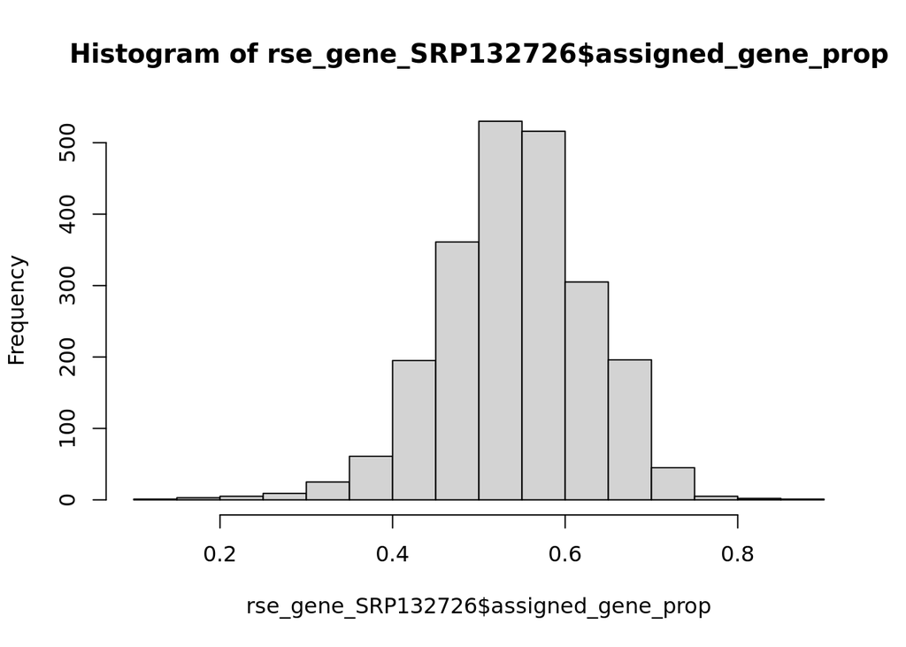

```r
# Tanto la proporcion de lecturas asignadas en general como para cada grupo
# indican que hay una gran brecha entre el minimo y el primer cuartil como
# entre el maximo con el 3er cuartil, por lo que se reduciran con un filtro

# Se hace un respaldo por seguridad
rse_gene_SRP132726_respaldo <- rse_gene_SRP132726

## Histograma explorativo
hist(rse_gene_SRP132726$assigned_gene_prop)
```

Luce como una distribución nomrla con orillas muy alargas.

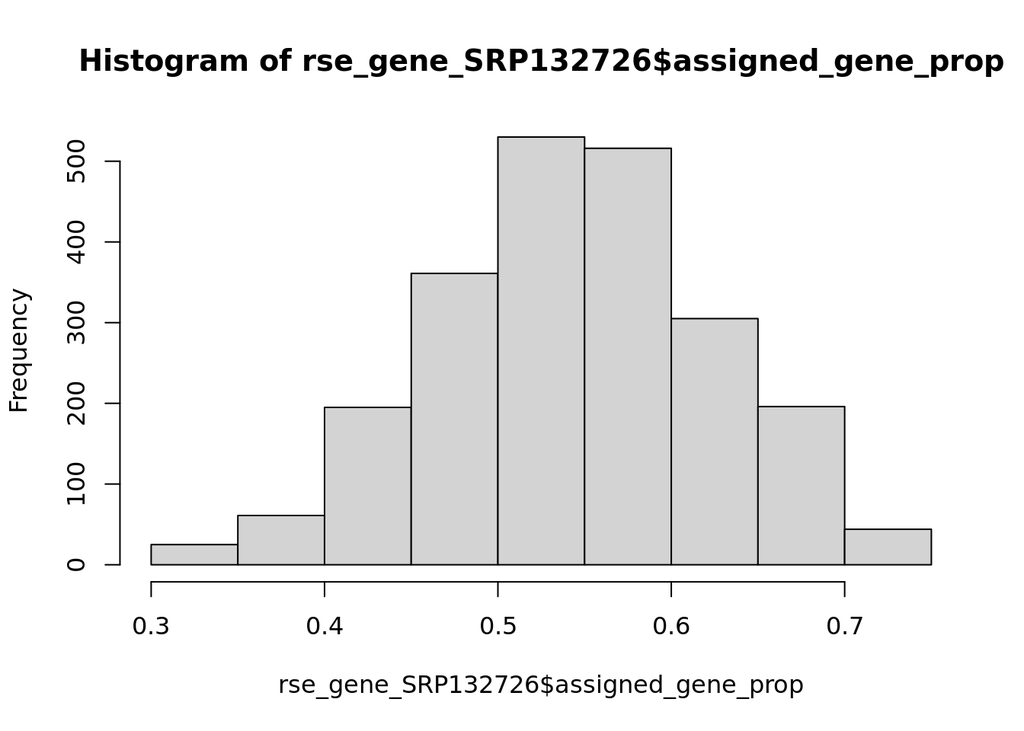

```r
# Aplicacion de los filtros
rse_gene_SRP132726 <- rse_gene_SRP132726[, rse_gene_SRP132726$assigned_gene_prop > 0.3]
rse_gene_SRP132726 <- rse_gene_SRP132726[, rse_gene_SRP132726$assigned_gene_prop < 0.75]

# Resultados
hist(rse_gene_SRP132726$assigned_gene_prop)
```

Las orillas se lograron reducir haciendo que nuestros datos estén menos dispersos.

```r
# Observamos los resultados
summary(rse_gene_SRP132726$assigned_gene_prop)
```

```
##    Min. 1st Qu.  Median    Mean 3rd Qu.    Max.
##  0.3050  0.4902  0.5461  0.5446  0.5984  0.7464
```

```r
with(colData(rse_gene_SRP132726), tapply(assigned_gene_prop, zika, summary))
```

```
## $Dengue
##    Min. 1st Qu.  Median    Mean 3rd Qu.    Max.
##  0.3050  0.4948  0.5533  0.5520  0.6149  0.7464
##
## $Zika
##    Min. 1st Qu.  Median    Mean 3rd Qu.    Max.
##  0.3067  0.4868  0.5390  0.5348  0.5788  0.7412
```

```r
# Se encuntran mas cercanos
```

```r
library("ggplot2")
```

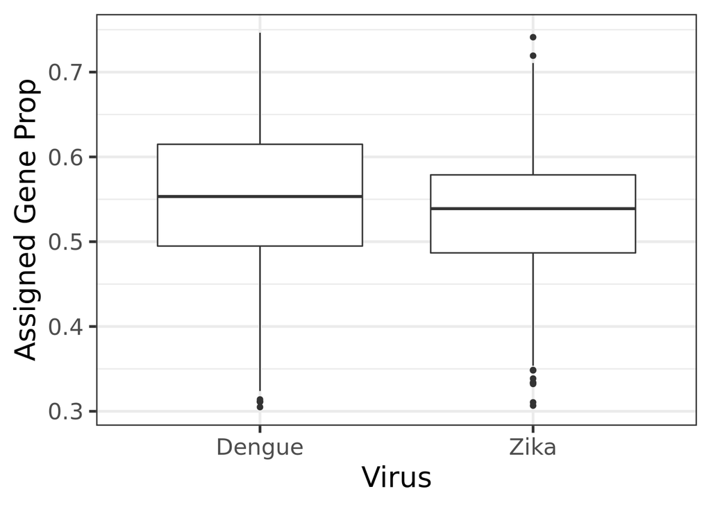

```r
# Ploteamos las diferencias entre calidades de ambos grupos
ggplot(as.data.frame(colData(rse_gene_SRP132726)), aes(y = assigned_gene_prop, x = zika)) +
    geom_boxplot() +
    theme_bw(base_size = 20) +
    ylab("Assigned Gene Prop") +
    xlab("Virus")
```

LAmbos grupos de datos tiene una proporción media de alredor del 55 por ciento.

```r
library("edgeR")
# Ahora resolvamos el composition bias para obervar la expresion diferencial
dge <- DGEList(
    counts = assay(rse_gene_SRP132726, "counts"),
    genes = rowData(rse_gene_SRP132726)
)
dge <- calcNormFactors(dge)
```

```r
# Genramos el modelo para este proyecto
mod <- model.matrix(~ zika
                    + sra_attribute.moi
                    + sra_attribute.n_dengue_molecules
                    + assigned_gene_prop,
    data = colData(rse_gene_SRP132726)
)
```

```r
# Mostramos los coeficientes
colnames(mod)
```

```
## [1] "(Intercept)"                      "zikaZika"
## [3] "sra_attribute.moi"                "sra_attribute.n_dengue_molecules"
## [5] "assigned_gene_prop"
```

```r
library("limma")
```

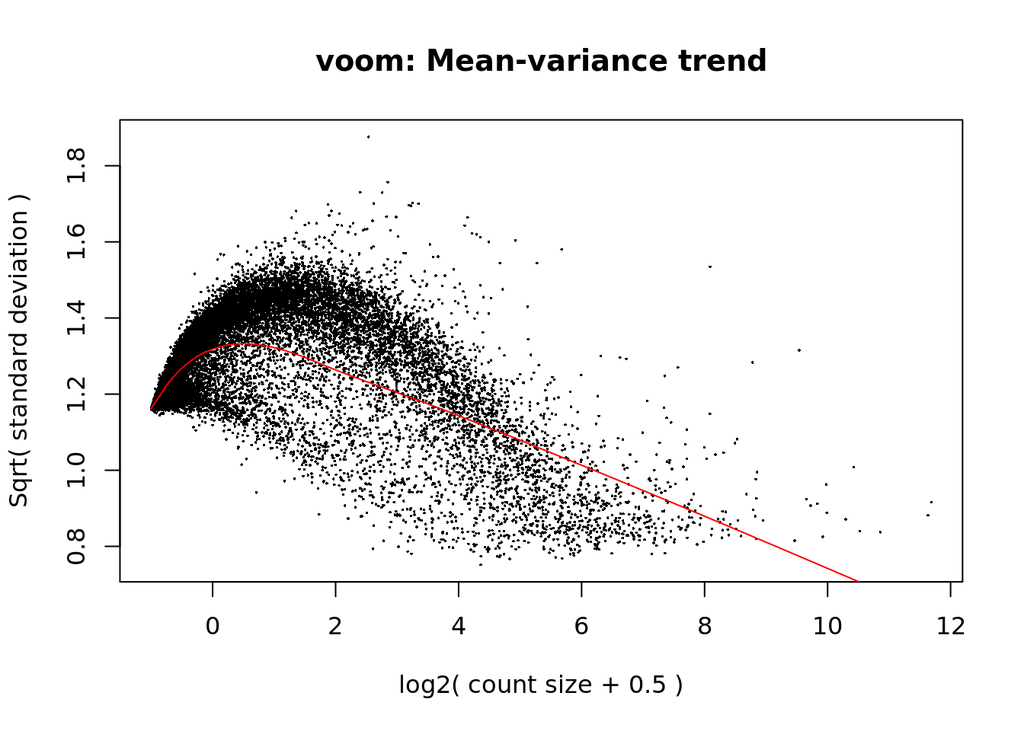

```r
# Gneramos un ploteo de la regresion linea de la expresion usando el modelo
vGene <- voom(dge, mod, plot = TRUE)
```

Observamos que existe una enorme cantidad de genes que se expresan muy poco o cantidades negativas a lo usual pero que estan muy cercanos al modelo de la regresión lineal, por el otro lado, exiten pocos genes que tienen una alta expresión con muchas desviasiones estandar.

```r
# Ahora generamos la tabla para el plteo del volcan y el heatmap
eb_results <- eBayes(lmFit(vGene))

de_results <- topTable(
    eb_results,
    coef = 2,
    number = nrow(rse_gene_SRP132726),
    sort.by = "none"
)
```

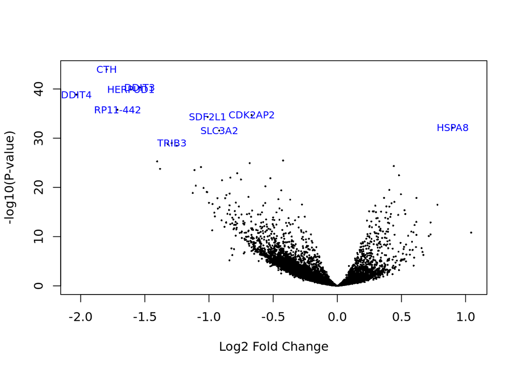

```r
# De este ploteo sacamos 4 genes con mayor expresión
volcanoplot(eb_results, coef = 2, highlight = 10, names = de_results$gene_name)
```

```r
# Se seleccionaron 3 con valores de x negativa y uno de valor positivo
```

Nos permite observar con mejor presición aquellos genes que tienen una expresión anormal.

```r
# Se muestran los datos de estos genes
de_results[de_results$gene_name %in% c("DDIT3", "HERPUD1", "CTH", "HSPA8"), ]
```

```
##                    source type score phase            gene_id      gene_type
## ENSG00000116761.11 HAVANA gene  2414    NA ENSG00000116761.11 protein_coding
## ENSG00000109971.13 HAVANA gene  4849    NA ENSG00000109971.13 protein_coding
## ENSG00000175197.11 HAVANA gene  1266    NA ENSG00000175197.11 protein_coding
## ENSG00000051108.14 HAVANA gene  5155    NA ENSG00000051108.14 protein_coding
##                    gene_name level          havana_gene               tag
## ENSG00000116761.11       CTH     2 OTTHUMG00000009352.1        ncRNA_host
## ENSG00000109971.13     HSPA8     1 OTTHUMG00000166030.2        ncRNA_host
## ENSG00000175197.11     DDIT3     2 OTTHUMG00000170046.3        ncRNA_host
## ENSG00000051108.14   HERPUD1     1 OTTHUMG00000133276.9 overlapping_locus
##                         logFC  AveExpr         t      P.Value    adj.P.Val
## ENSG00000116761.11 -1.7976434 3.294644 -14.34081 1.040321e-44 6.643072e-40
## ENSG00000109971.13  0.8992148 9.877154  12.12779 7.669492e-33 6.121788e-29
## ENSG00000175197.11 -1.5402053 5.802214 -13.68879 4.865868e-41 1.553574e-36
## ENSG00000051108.14 -1.6096150 6.877460 -13.60877 1.342044e-40 2.856586e-36
##                           B
## ENSG00000116761.11 88.93469
## ENSG00000109971.13 63.67391
## ENSG00000175197.11 81.43016
## ENSG00000051108.14 80.74787
```

```r
# ENSG00000175197.11, ENSG00000051108.14, ENSG00000116761.11, ENSG00000109971.13
```

```r
## Extraer valores de los genes de interés, podemos trabajar con 10
exprs_heatmap <- vGene$E[rank(de_results$adj.P.Val) <= 10, ]

## Creemos una tabla con información de las muestras
## y con nombres de columnas más amigables
df <- as.data.frame(colData(rse_gene_SRP132726)[, c("zika", "sra_attribute.moi",
                                                    "sra_attribute.n_dengue_molecules")])
colnames(df) <- c("Virus", "MOI", "MoleDengue")

# Obtenemos y aplicamos nombres de los genes
rownames(exprs_heatmap) <- rowRanges(rse_gene_SRP132726)$gene_name[
  match(rownames(exprs_heatmap), rowRanges(rse_gene_SRP132726)$gene_id)
]
```

```r
library("pheatmap")
```

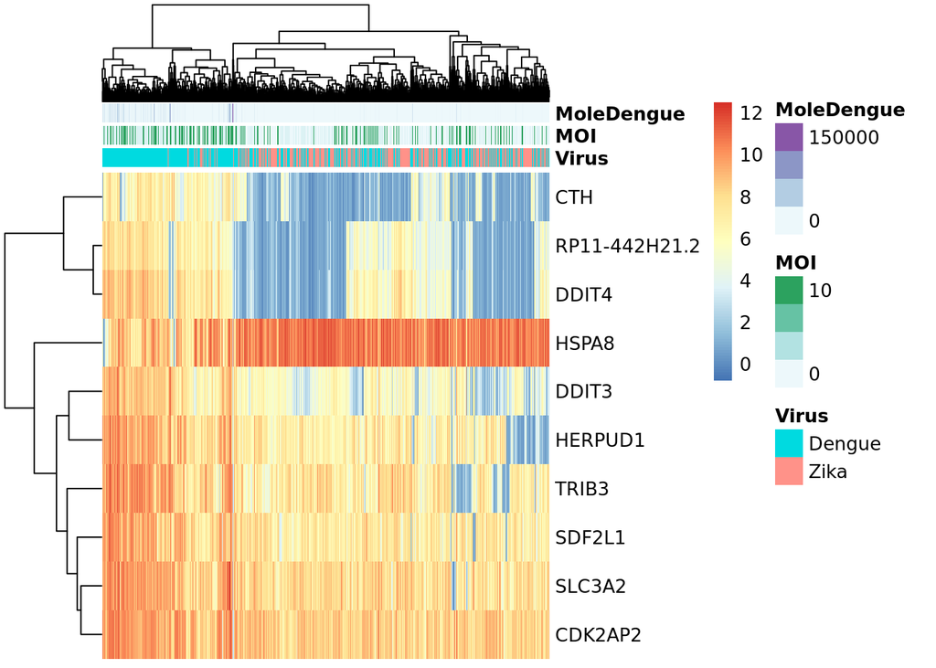

```r
# Ploteo del heatmap
pheatmap(
    exprs_heatmap,
    cluster_rows = TRUE,
    cluster_cols = TRUE,
    show_rownames = TRUE,
    show_colnames = FALSE,
    annotation_col = df
)
```

El gen que resulata más es el HSPA8, el cual tiene una gran expresión a lo largo de las muestras, sobre todo en aquellas que son parte del segundo grupo formado por el dendrograma superior. Los otros genes antes mencionados también resaltan pero tener una expresión especialmente baja.

```r
# Como ultimo paso se decidio sacar en plots la expresion de los gens antes mencionados
library(iSEE)
```

Por problemas con la exportacion del rmd a html se dejaran los vinculos a las imagnes en pdf depositadas en este mismo respositorio

- [CTH](https://github.com/eduardo-arrieta/PROYECTO_RNA-seq_2021/blob/master/figuras/CTH.pdf)
- [DDIT3](https://github.com/eduardo-arrieta/PROYECTO_RNA-seq_2021/blob/master/figuras/DDIT3.pdf)
- [HERPUD1](https://github.com/eduardo-arrieta/PROYECTO_RNA-seq_2021/blob/master/figuras/HERPUD1.pdf)
- [HSPA8](https://github.com/eduardo-arrieta/PROYECTO_RNA-seq_2021/blob/master/figuras/HSPA8.pdf)

Los figuras estan dividas en columnas donde cada una es un grupo de infección y los colores representan la calidad de las lecturas

CTH: Cistationina gamma-liasa, cataliza el último paso en la vía de trans-sulfuración de metionina a cisteína.

DDIT3: Proteína del transcrito 3 inducible por daños en el ADN, factor de transcripción multifuncional en la respuesta al estrés del retículo endoplásmico. Desempeña un papel esencial en la respuesta a una amplia variedad de tensiones celulares e induce la detención del ciclo celular y la apoptosis en respuesta al estrés ER

HERPUD1: Proteína miembro 1 del dominio similar a ubiquitina residente en retículo endoplásmico sensible a homocisteína, Componente del sistema de control de calidad del retículo endoplásmico (ERQC) también llamado degradación asociada a ER (ERAD) involucrado en la degradación dependiente de ubiquitina de proteínas del retículo endoplásmico mal plegadas.

HSPA8: Chaperona molecular implicada en una amplia variedad de procesos celulares, incluida la protección del proteoma del estrés, el plegamiento y transporte de polipéptidos recién sintetizados, la activación de la proteólisis de proteínas mal plegadas y la formación y disociación de complejos proteicos. Desempeña un papel fundamental en el sistema de control de calidad de las proteínas, asegurando el plegado correcto de las proteínas, el plegado de proteínas mal plegadas y controlando la orientación de las proteínas para su posterior degradación.

Como era de esperarse, el conteo de la expresión de HSPA8 se encontró en gran cantidad, pero, a diferencia de las anteriores tres, esta se manifestó más en infecciones con el segundo grupo, el sika, por lo que da una pista a que las interacción huesped-hospedero que se dan con este virus están mas relacinados al este gen, que junto DDIT3 es un importante agente en la regulación.